# Portfolio Assessment: Performance and selling strategies

2021-03-03

A timely retreat is a victory.

### Our portfolio`

Portfolio

| Ticker | nShares | AP | ADate | CP | CV | weight |
| --- | --- | --- | --- | --- | --- | --- |
| MC.PA | 14 | 350.00 | 2020-05-01 | 543.80 | 7613.20 | 0.1716392 |
| DGV.MI | 165 | 30.50 | 2020-11-01 | 44.00 | 7260.00 | 0.1636763 |
| PUM.DE | 80 | 55.40 | 2020-04-01 | 86.50 | 6920.00 | 0.1560110 |
| AZO | 5 | 1135.00 | 2020-11-01 | 1179.74 | 5898.70 | 0.1329859 |
| SPGI | 15 | 350.00 | 2020-11-01 | 326.53 | 4897.95 | 0.1104240 |
| UNA.AS | 100 | 46.00 | 2020-12-07 | 44.11 | 4411.00 | 0.0994458 |
| AAPL | 32 | 132.52 | 2021-02-01 | 122.06 | 3905.92 | 0.0880588 |
| COST | 6 | 362.00 | 2021-01-01 | 323.92 | 1943.52 | 0.0438166 |
| BBY | 15 | 107.00 | 2020-12-01 | 100.37 | 1505.55 | 0.0339425 |

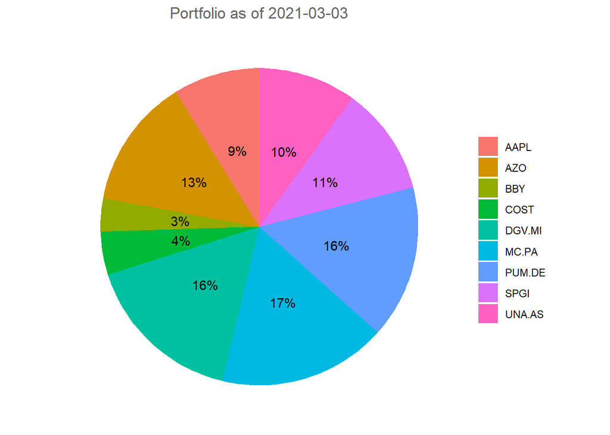

### Factor 1: Quality

1. Healthy debts: A company shoud generate cash in order to repay its debt. The **Free Cash Flow to Debt** ratio is a good indicator of how quick a company pays back its debt. The lower this ratio the better.

FCF2D = $\frac{Debt}{Free Cash Flow}$

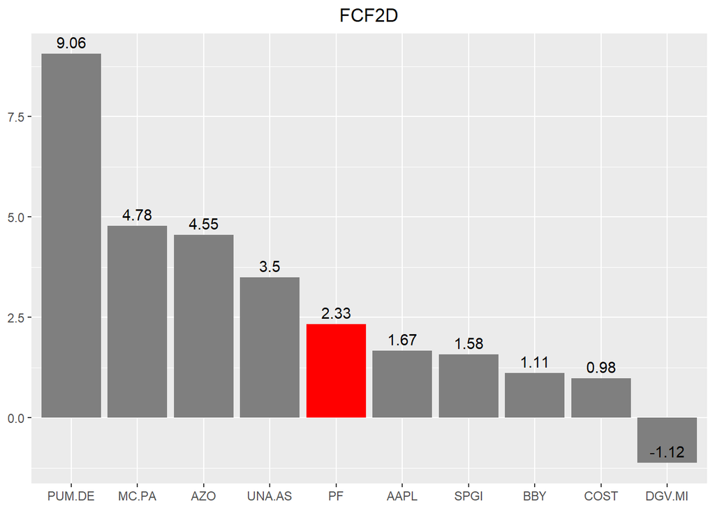

2. Profitability: ROA

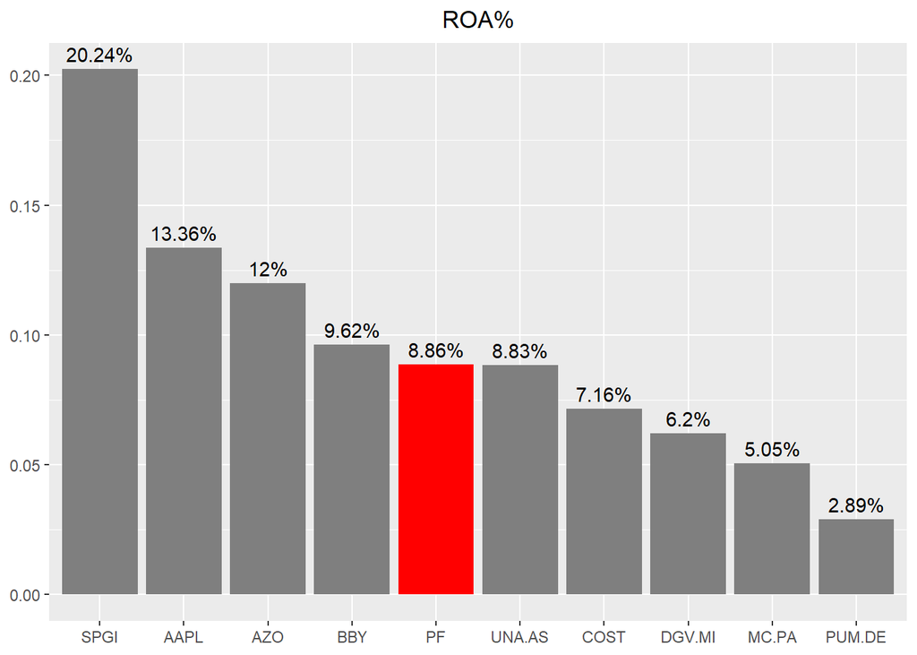

3. High Margin: We look for companies that generate free cash flow compare to its price. The **Free Cash Flow to Entreprise Value** ratio tells us how many years of cash flow would be needed to the return the 100% of the investment. Again, the lower, the better. Values bellow 1 would mean "free lunch".

FCF2EV = $\frac{EV}{Free Cash Flow}$

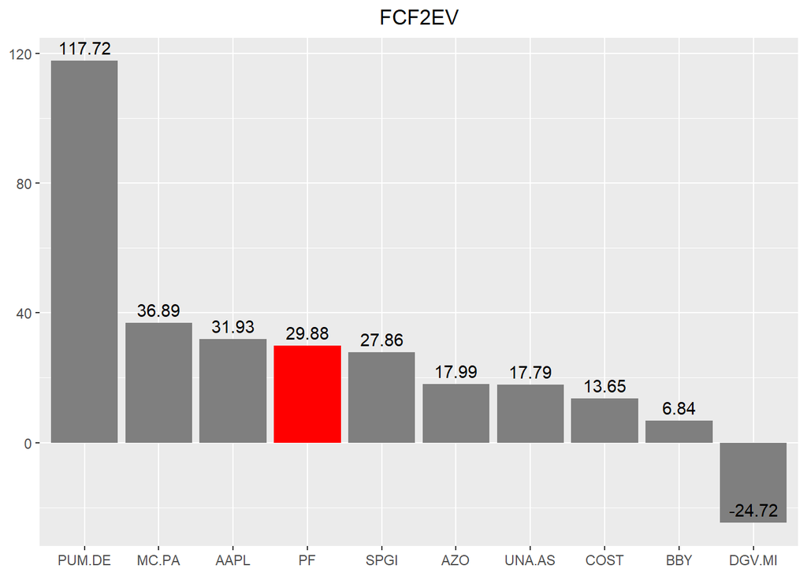

### Factor 2: Momentum

Don't hold onto a stock simply because it is high quality. So called quality stocks have cycles too. Stan Weinstein (page 177)

Generic Intermediate-Term Momentum Based on Gray-Vogel (page 80)

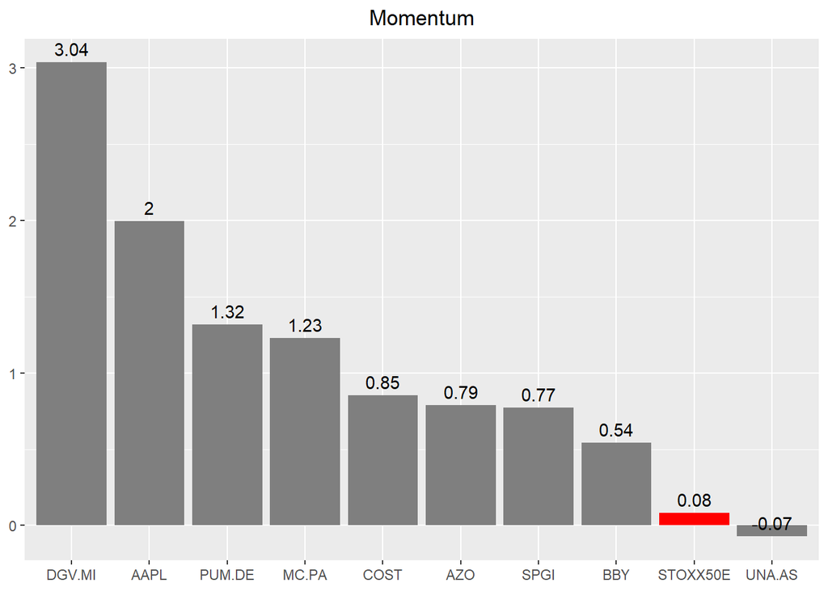

### Factor 3: Timing Signal

Sell Signal - Pr < 1% SMA 30 weeks and slope negative (< 0.1)  
Hold Signal - No Sell

**StopLoss for the next month**

If Profit > 20%, Trailing Stop Loss (Max - 20%) If Profit < 20%, Stop Loss (AP - 15%)

### Summary

Summary

| Ticker | AP | CP | weight | StopLoss | Signal | Quality | Momentum | Final_rank |
| --- | --- | --- | --- | --- | --- | --- | --- | --- |
| AAPL | 132.52 | 122.06 | 0.0881 | 112.64 | HOLD | 6.0 | 8 | 9.0 |
| COST | 362.00 | 323.92 | 0.0438 | 307.70 | HOLD | 7.5 | 5 | 8.0 |
| BBY | 107.00 | 100.37 | 0.0339 | 90.95 | HOLD | 9.0 | 2 | 7.0 |
| DGV.MI | 30.50 | 44.00 | 0.1637 | 35.20 | HOLD | 1.5 | 9 | 5.5 |
| SPGI | 350.00 | 326.53 | 0.1104 | 297.50 | HOLD | 7.5 | 3 | 5.5 |
| MC.PA | 350.00 | 543.80 | 0.1716 | 435.04 | HOLD | 3.0 | 6 | 4.0 |
| PUM.DE | 55.40 | 86.50 | 0.1560 | 73.55 | HOLD | 1.5 | 7 | 2.5 |
| AZO | 1135.00 | 1179.74 | 0.1330 | 964.75 | HOLD | 4.5 | 4 | 2.5 |
| UNA.AS | 46.00 | 44.11 | 0.0994 | 39.10 | SELL | 4.5 | 1 | 1.0 |